# Beta diversity

Yanxian Li Department of Paraclinical Sciences Faculty of Veterinary Medicine Norwegian University of Life Sciences

2021-07-27

# 1 Getting ready

Load packages

```r
library(here) # A Simpler Way to Find Your Files, CRAN
library(tidyverse) # Easily Install and Load the 'Tidyverse', CRAN
library(patchwork) # The Composer of Plots, CRAN
library(flextable) # Functions for Tabular Reporting, CRAN
library(usedist) # Distance Matrix Utilities
library(vegan) # Community Ecology Package, CRAN
```

Load function.

```r
source(here("code/functions/plot_betadisper.R"))
```

Load data

```r
# metadata
mtd <- read_tsv(here("data/metadata.tsv"), comment = "#q2") %>%
  rename(SampleID = "#SampleID") %>%
  filter(Species == "Nile tilapia") %>%
  mutate(
    Population = factor(Population, levels = c("Farmed", "Wild")),
    Environment = factor(Environment, levels = c("Pond", "Lake"))
  )

# distance matrix
dist <- readRDS(here("data/intermediate/qiime2R/tilapia/beta_diversity_distance.rds"))
dist_atch <- dist$aitchison$data # Aitchison distance
dist_wuf <- dist$weighted_unifrac$data # weighted UniFrac distance

# ordination
ord <- readRDS(here("data/intermediate/qiime2R/tilapia/beta_diversity_ordination.rds"))
ord_atch <- ord$aitchison$data # Aitchison distance based PCoA
ord_wuf <- ord$weighted_unifrac$data # weighted UniFrac distance based PCoA
```

# 2 Ordination

Unweighted beta-diversity distance metrics such as unweighted UniFrac are subjective to technical noises, making comparison of results across studies difficult ([Wong et al., 2016](https://doi.org/10.1371/journal.pone.0161196); [Nearing et al., 2018](https://doi.org/10.7717/peerj.5364)). Here we use weighted distance metrics including robust Aitchison distance and weighted UniFrac distance to compare beta-diversity. Robust Aitchison distance is a compositional beta diversity metric rooted in a centered log-ratio (CLR) transformation and matrix completion [(Martino et al., 2019)](https://msystems.asm.org/content/4/1/e00016-19). It has some desirable properties: 1)scale invariant, which ensures equivalence between distances computed from absolute and relative abundance measurements, negating the need to perform rarefaction; 2)relative changes driven. Microbes that display large fold change across samples will be weighted more heavily, which makes the ordination robust to random fluctuations of high-abundant taxa; 3)sub-compositionally coherent, which guarantees that distances will never decrease if additional taxa are observed.

## 2.1 PCoA: robust Aitchison distance

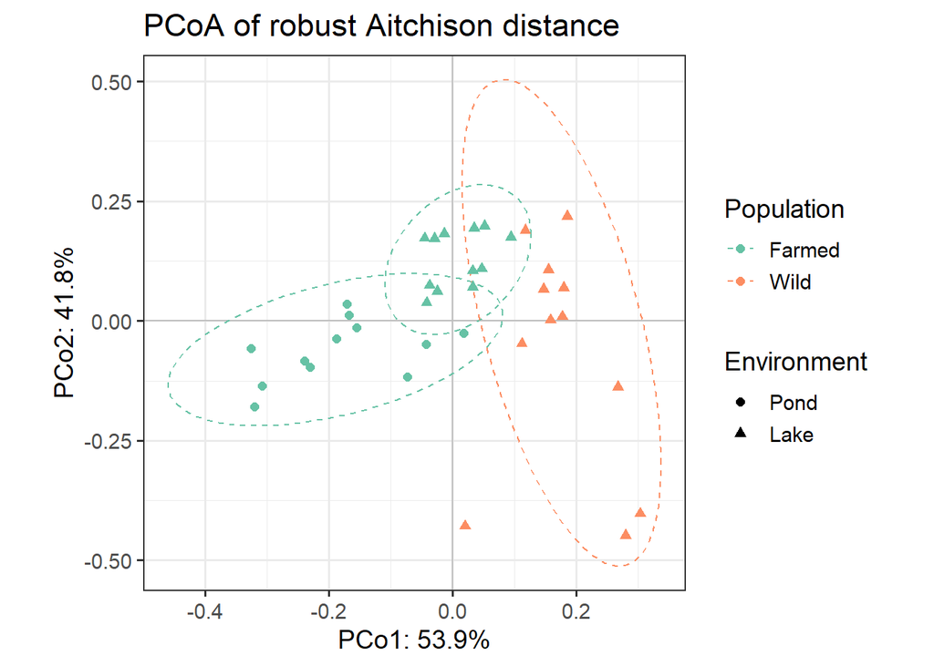

```r
pcoa_atch <- ord_atch$Vectors %>%
  mutate(
    SampleID = as.character(SampleID),
    SampleID = ifelse(nchar(SampleID) < 2, paste0("0", SampleID), SampleID)
    ) %>%
  inner_join(mtd, by = "SampleID") %>%
  ggplot(aes(x = PC1, y = PC2, color = Population, shape = Environment)) +
    geom_hline(yintercept = 0, color = "grey") +
    geom_vline(xintercept = 0, color = "grey") +
    # data ellipse
    stat_ellipse(linetype = "dashed") +
    geom_point(size = 2) +
    # keep the aspect ratio between y and x axis (y-axis/x-axis)
    coord_fixed(ord_atch$ProportionExplained[2]/ord_atch$ProportionExplained[1]) +
    labs(
      x = paste0("PCo1: ", round(100 * ord_atch$ProportionExplained[1], 1), "%"),
      y = paste0("PCo2: ", round(100 * ord_atch$ProportionExplained[2], 1), "%")
      ) +
    scale_color_brewer(palette = "Set2") +
    theme_bw(base_size = 14)

pcoa_atch + labs(title = "PCoA of robust Aitchison distance")
```

## 2.2 PCoA: weighted UniFrac distance

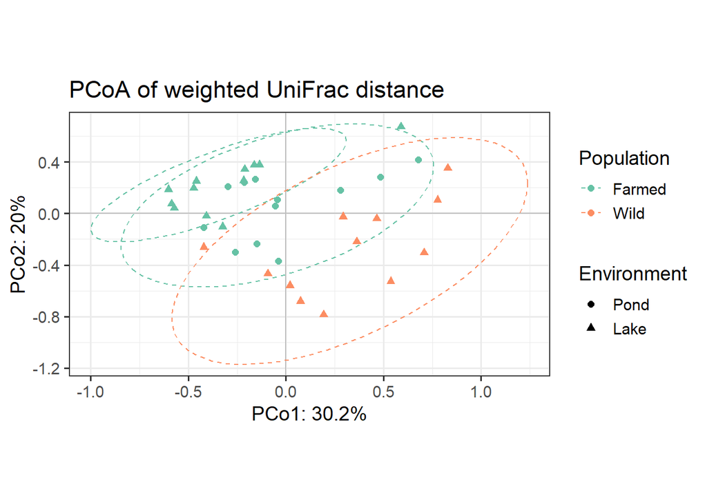

```r
pcoa_wuf <- ord_wuf$Vectors %>%
  mutate(
    SampleID = as.character(SampleID),
    SampleID = ifelse(nchar(SampleID) < 2, paste0("0", SampleID), SampleID)
    ) %>%
  inner_join(mtd, by = "SampleID") %>%
  ggplot(aes(x = PC1, y = PC2, color = Population, shape = Environment)) +
    geom_hline(yintercept = 0, color = "grey") +
    geom_vline(xintercept = 0, color = "grey") +
    stat_ellipse(linetype = "dashed") +
    geom_point(size = 2) +
    coord_fixed(ord_wuf$ProportionExplained[2]/ord_wuf$ProportionExplained[1]) +
    labs(
      x = paste0("PCo1: ", round(100 * ord_wuf$ProportionExplained[1], 1), "%"),
      y = paste0("PCo2: ", round(100 * ord_wuf$ProportionExplained[2], 1), "%")
      ) +
    scale_color_brewer(palette = "Set2") +
    theme_bw(base_size = 14)

pcoa_wuf + labs(title = "PCoA of weighted UniFrac distance")
```

## 2.3 Figure 4

Assemble plots.

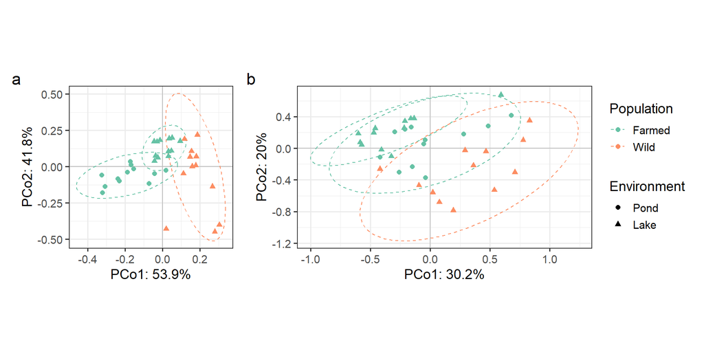

```r
pcoa_atch + pcoa_wuf +
  plot_layout(guides = "collect") +
  plot_annotation(tag_levels = "a")
```

```r
# export plot
ggsave(here("result/figure/tilapia/Figure 4.tiff"), width = 10, units = "in",
       dpi = 300, compression = "lzw")
```

# 3 PERMANVOA

## 3.1 Export distance matrix

We export the distance matrices and run PERMANOVA using the PERMANOVA+ add-on from the [PRIMER v7](https://www.primer-e.com/our-software/permanova-add-on/).

```r
# combine distance matrices into a list
dist_list <- list(dist_atch, dist_wuf)
names(dist_list) <- c("Aitchison_distance", "Weighted_UniFrac_distance")

# export distance matrices
lapply(seq_along(dist_list), function(x) {
  dist_list[[x]] %>%
    as.matrix() %>%
    as.data.frame() %>%
    write.table(
      here(
        paste0("data/intermediate/permanova/tilapia/", names(dist_list)[x], ".tsv")
        ),
      sep = "\t",
      col.names = NA,
      row.names = TRUE)
    }
  )
```

## 3.2 Import and format PERMANVOA results

```r
# import permanova results
permanova <- read_csv(
  here("data/intermediate/permanova/tilapia/permanova_results.csv")
  )

# format permanova results
permanova %>%
  # the following 4 lines of code adjust raw p values
  group_nest(Distance, Comparison) %>%
  mutate(P_adj = map(data, ~p.adjust(.x$P, method = "holm"))) %>%
  unnest(cols = c(data, P_adj)) %>%
  ungroup() %>%
  mutate(
    Comparison = gsub(
      "Tilapia_farmed_pond - Tilapia_farmed_lake",
      "farmed tilapia",
      Comparison
      ),
    Comparison = gsub(
      "Tilapia_farmed_lake - Tilapia_wild_lake",
      "tilapia in lake",
      Comparison
      ),
    Comparison = factor(
      Comparison, levels = c("farmed tilapia", "tilapia in lake")
      ),
    Term = gsub("Environment", "Environment (Pond vs Lake)", Term),
    Term = gsub("Population", "Population (Farmed vs Wild)", Term),
    P = P_adj
    ) %>%
  select(-P_adj) %>%
  arrange(Distance, Comparison) %>%
  flextable() %>%
  set_caption(
    caption = "Table 1. PERMANOVA results based on robust Aitchison and weighted UniFrac distance."
    ) %>%
  autofit() %>%
  italic(j = 5:6, italic = TRUE, part = "head") %>% # italicize column names
  merge_v(j = c("Distance", "Comparison")) %>% # merge cells by phylum
  theme_booktabs() %>% # apply table style
  hline(i = c(3, 6, 9), part = "body") # draw horizontal lines
```

Table 1. PERMANOVA results based on robust Aitchison and weighted UniFrac distance.

| Distance | Comparison | Term | df | Pseudo-F | P |
| --- | --- | --- | --- | --- | --- |
| robust Aitchison | farmed tilapia | Environment (Pond vs Lake) | 1 | 13.66 | 0.013 |
|  |  | Site | 7 | 7.84 | 0.002 |
|  |  | Residual | 15 |  |  |
|  | tilapia in lake | Population (Farmed vs Wild) | 1 | 14.26 | 0.002 |
|  |  | Site | 5 | 3.47 | 0.012 |
|  |  | Residual | 17 |  |  |
| weighted UniFrac | farmed tilapia | Environment (Pond vs Lake) | 1 | 2.62 | 0.011 |
|  |  | Site | 7 | 3.00 | 0.004 |
|  |  | Residual | 15 |  |  |
|  | tilapia in lake | Population (Farmed vs Wild) | 1 | 8.49 | 0.002 |
|  |  | Site | 5 | 1.19 | 0.247 |
|  |  | Residual | 17 |  |  |

# 4 PERMDISP

PERMANOVA tests differences in both location and dispersion effects. Although PERMANOVA is robust to heterogeneity in the multivariate dispersion, it’s a good practice to look at the homogeneity of multivariate dispersion following a significant PERMANVOA result. The homogeneity of multivariate dispersion can be assessed visually (PCoA plot/boxplot) or via a permutation test called PERMDISP, which is implemented in R by the `betadisper()` function from the *vegan* package. As within-group sample sizes are small (n < 5) in the present study, formal testing using PERMDISP is not meaningful. We’ll visually assess the homogeneity of multivariate dispersion.

## 4.1 Robust Aitchison distance

### 4.1.1 Farmed tilapia: pond vs lake

Subset distance matrix.

```r
mtd_farmed <- filter(mtd, Population == "Farmed")
dist_atch_farmed <- dist_subset(dist_atch, mtd_farmed$SampleID)
```

#### 4.1.1.1 Site-level

First, we check the equality of dispersion for samples (replicates) across different Site (centroids).

Compute beta-dispersion.

```r
(disp_atch_farmed_site <- betadisper(
  d = dist_atch_farmed,
  group = mtd_farmed$Site,
  type = "median",
  bias.adjust = TRUE
  ))
```

```
##
##  Homogeneity of multivariate dispersions
##
## Call: betadisper(d = dist_atch_farmed, group = mtd_farmed$Site, type = "median", bias.adjust = TRUE)
##
## No. of Positive Eigenvalues: 3
## No. of Negative Eigenvalues: 0
##
## Average distance to median:
##  Jinja_Lake_site1 Mukono_Lake_site1 Mukono_Lake_site2     Mukono_Pond_1     Mukono_Pond_2 Wakiso_Lake_site2
##            0.3065            0.1507            0.3347            0.3532               NaN            0.3221
##     Wakiso_Pond_1     Wakiso_Pond_2     Wakiso_Pond_3
##            0.3705            0.3753            0.3389
##
## Eigenvalues for PCoA axes:
##  PCoA1  PCoA2  PCoA3
## 22.301  2.618  1.014
```

Visual inspection.

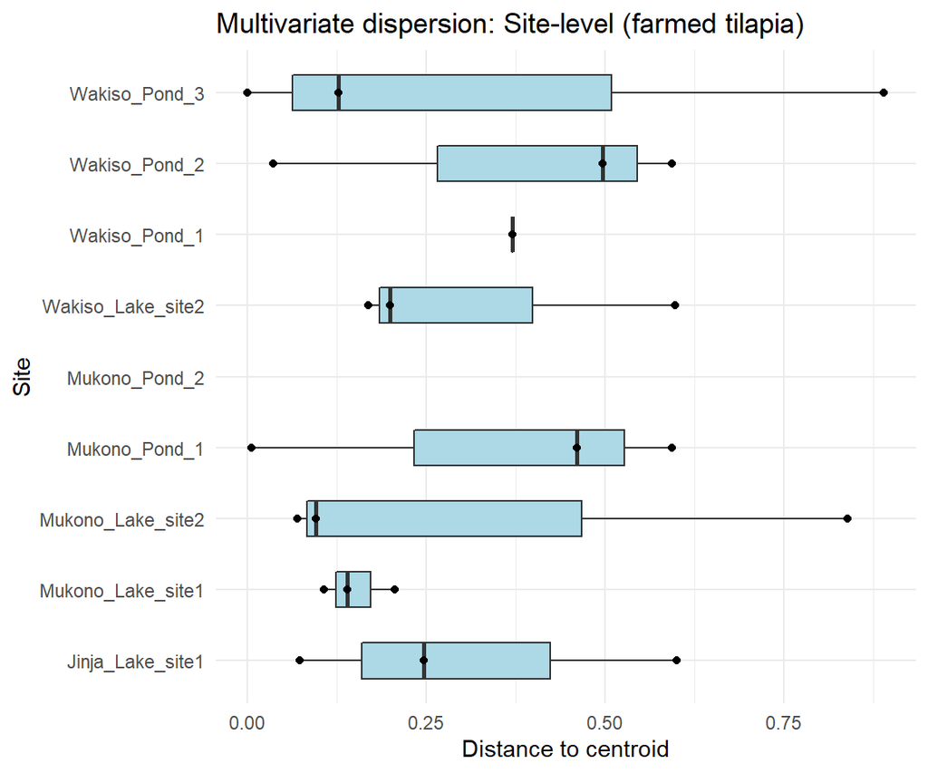

```r
plot_betadisper(
  disp_atch_farmed_site,
  xlab = "Site",
  title = "Multivariate dispersion: Site-level (farmed tilapia)") +
  coord_flip()
```

#### 4.1.1.2 Environment-level

Next, we consider differences in the dispersion of Site centroids around the Environment centroids.

Compute distance among the Site centroids.

```r
dist_atch_farmed_site <- dist_multi_centroids(dist_atch_farmed, mtd_farmed$Site)
```

Make a new metadata matching Site and Environment.

```r
mtd_farmed_site <- mtd_farmed %>%
  select(Environment, Site) %>%
  distinct()%>%
  arrange(Site)
```

Compute beta-dispersion.

```r
(disp_atch_farmed_env <- betadisper(
  d = dist_atch_farmed_site,
  group = mtd_farmed_site$Environment,
  type = "median",
  bias.adjust = TRUE
  ))
```

```
##
##  Homogeneity of multivariate dispersions
##
## Call: betadisper(d = dist_atch_farmed_site, group = mtd_farmed_site$Environment, type = "median",
## bias.adjust = TRUE)
##
## No. of Positive Eigenvalues: 3
## No. of Negative Eigenvalues: 0
##
## Average distance to median:
##   Pond   Lake
## 0.5764 0.4289
##
## Eigenvalues for PCoA axes:
##  PCoA1  PCoA2  PCoA3
## 7.2963 0.6668 0.2609
```

Visual inspection.

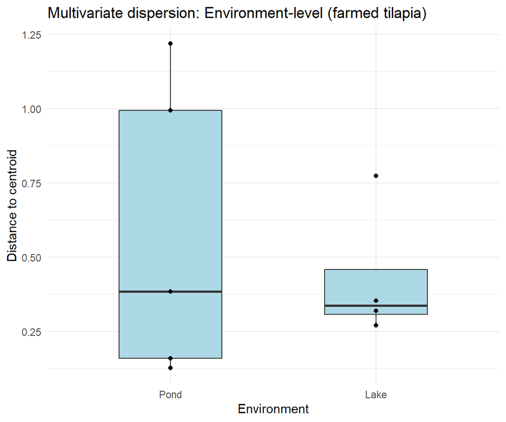

```r
plot_betadisper(
  disp_atch_farmed_env,
  xlab = "Environment",
  title = "Multivariate dispersion: Environment-level (farmed tilapia)")
```

### 4.1.2 Tilapia in lake: farmed vs wild

Subset distance matrix.

```r
mtd_lake <- filter(mtd, Environment == "Lake") %>%
  mutate(Site = paste0(Population, "_", Site))

dist_atch_lake <- dist_subset(dist_atch, mtd_lake$SampleID)
```

#### 4.1.2.1 Site-level

Compute beta-dispersion.

```r
(disp_atch_lake_site <- betadisper(
  d = dist_atch_lake,
  group = mtd_lake$Site,
  type = "median",
  bias.adjust = TRUE
  ))
```

```
##
##  Homogeneity of multivariate dispersions
##
## Call: betadisper(d = dist_atch_lake, group = mtd_lake$Site, type = "median", bias.adjust = TRUE)
##
## No. of Positive Eigenvalues: 3
## No. of Negative Eigenvalues: 0
##
## Average distance to median:
##  Farmed_Jinja_Lake_site1 Farmed_Mukono_Lake_site1 Farmed_Mukono_Lake_site2 Farmed_Wakiso_Lake_site2
##                   0.3065                   0.1507                   0.3347                   0.3221
##    Wild_Jinja_Lake_site2   Wild_Mukono_Lake_site1   Wild_Wakiso_Lake_site1   Wild_Wakiso_Lake_site2
##                   0.4715                   0.4583                   1.3453                   0.7926
##
## Eigenvalues for PCoA axes:
##  PCoA1  PCoA2  PCoA3
## 35.411  6.583  1.654
```

Visual inspection.

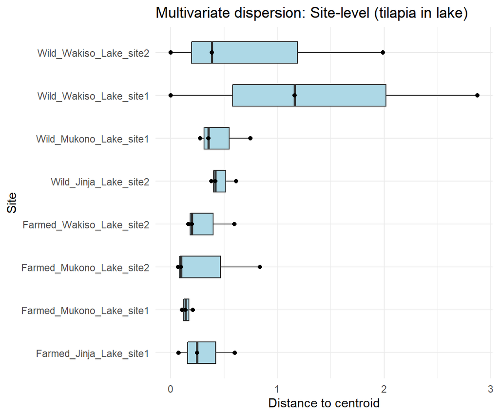

```r
plot_betadisper(
  disp_atch_lake_site,
  xlab = "Site",
  title = "Multivariate dispersion: Site-level (tilapia in lake)") +
  coord_flip()
```

#### 4.1.2.2 Population-level

Compute distance among the Site centroids.

```r
dist_atch_lake_site <- dist_multi_centroids(dist_atch_lake, mtd_lake$Site)
```

Make a new metadata matching Site and Population.

```r
mtd_lake_site <- mtd_lake %>%
  select(Population, Site) %>%
  distinct()%>%
  arrange(Site)
```

Compute beta-dispersion.

```r
(disp_atch_lake_pop <- betadisper(
  d = dist_atch_lake_site,
  group = mtd_lake_site$Population,
  type = "median",
  bias.adjust = TRUE
  ))
```

```
##
##  Homogeneity of multivariate dispersions
##
## Call: betadisper(d = dist_atch_lake_site, group = mtd_lake_site$Population, type = "median", bias.adjust =
## TRUE)
##
## No. of Positive Eigenvalues: 3
## No. of Negative Eigenvalues: 0
##
## Average distance to median:
## Farmed   Wild
## 0.4289 1.2685
##
## Eigenvalues for PCoA axes:
## PCoA1 PCoA2 PCoA3
## 9.830 1.335 0.307
```

Visual inspection.

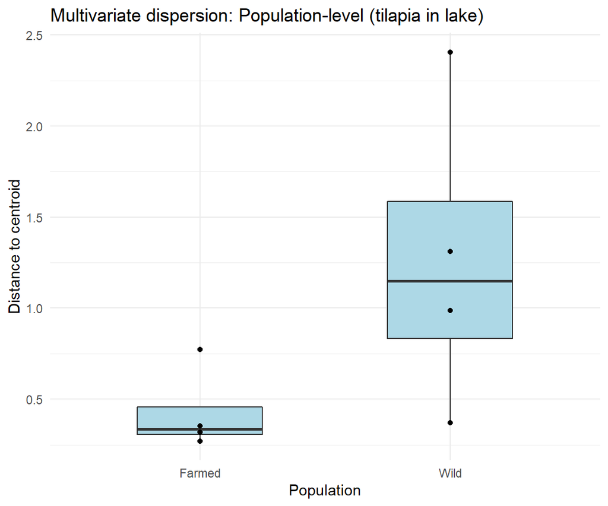

```r
plot_betadisper(
  disp_atch_lake_pop,
  xlab = "Population",
  title = "Multivariate dispersion: Population-level (tilapia in lake)")
```

## 4.2 Weighted UniFrac distance

### 4.2.1 Farmed tilapia: pond vs lake

Subset distance matrix.

```r
dist_wuf_farmed <- dist_subset(dist_wuf, mtd_farmed$SampleID)
```

#### 4.2.1.1 Site-level

Compute beta-dispersion.

```r
(disp_wuf_farmed_site <- betadisper(
  d = dist_wuf_farmed,
  group = mtd_farmed$Site,
  type = "median",
  bias.adjust = TRUE
  ))
```

```
##
##  Homogeneity of multivariate dispersions
##
## Call: betadisper(d = dist_wuf_farmed, group = mtd_farmed$Site, type = "median", bias.adjust = TRUE)
##
## No. of Positive Eigenvalues: 17
## No. of Negative Eigenvalues: 6
##
## Average distance to median:
##  Jinja_Lake_site1 Mukono_Lake_site1 Mukono_Lake_site2     Mukono_Pond_1     Mukono_Pond_2 Wakiso_Lake_site2
##           0.69267           0.07687           0.17568           0.34740               NaN           0.35793
##     Wakiso_Pond_1     Wakiso_Pond_2     Wakiso_Pond_3
##           0.27927           0.49951           0.26064
##
## Eigenvalues for PCoA axes:
## (Showing 8 of 23 eigenvalues)
##  PCoA1  PCoA2  PCoA3  PCoA4  PCoA5  PCoA6  PCoA7  PCoA8
## 3.7001 2.3002 1.0215 0.6834 0.3580 0.3010 0.2161 0.1782
```

Visual inspection.

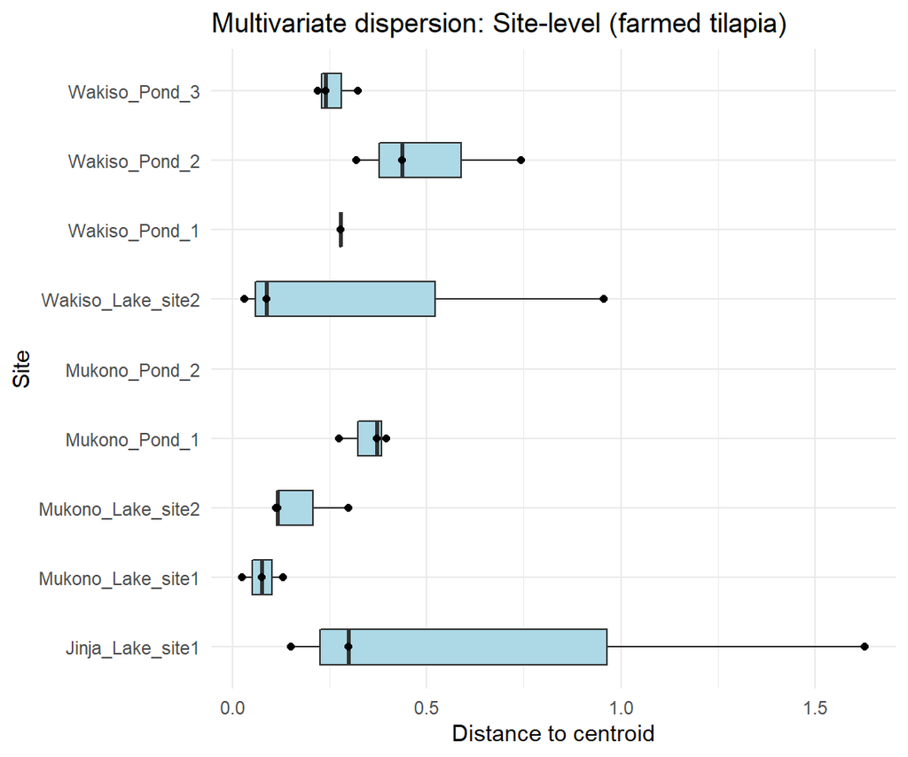

```r
plot_betadisper(
  disp_wuf_farmed_site,
  xlab = "Site",
  title = "Multivariate dispersion: Site-level (farmed tilapia)") +
  coord_flip()
```

#### 4.2.1.2 Environment-level

Compute distance among the Site centroids.

```r
dist_wuf_farmed_site <- dist_multi_centroids(dist_wuf_farmed, mtd_farmed$Site)
```

Compute beta-dispersion.

```r
(disp_wuf_farmed_env <- betadisper(
  d = dist_wuf_farmed_site,
  group = mtd_farmed_site$Environment,
  type = "median",
  bias.adjust = TRUE
  ))
```

```
##
##  Homogeneity of multivariate dispersions
##
## Call: betadisper(d = dist_wuf_farmed_site, group = mtd_farmed_site$Environment, type = "median",
## bias.adjust = TRUE)
##
## No. of Positive Eigenvalues: 7
## No. of Negative Eigenvalues: 1
##
## Average distance to median:
##   Pond   Lake
## 0.4831 0.3561
##
## Eigenvalues for PCoA axes:
##    PCoA1    PCoA2    PCoA3    PCoA4    PCoA5    PCoA6    PCoA7    PCoA8
##  0.94536  0.55528  0.36970  0.12384  0.07375  0.05362  0.01462 -0.02711
```

Visual inspection.

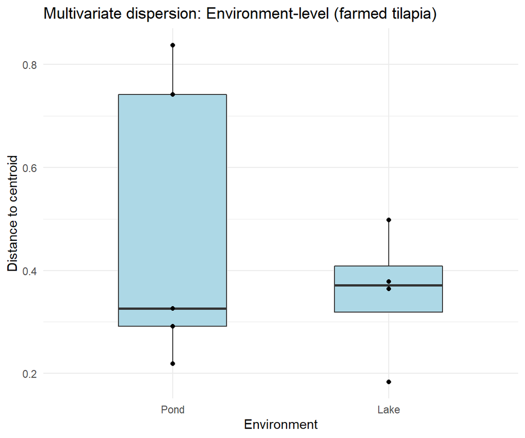

```r
plot_betadisper(
  disp_wuf_farmed_env,
  xlab = "Environment",
  title = "Multivariate dispersion: Environment-level (farmed tilapia)")
```

### 4.2.2 Tilapia in lake: farmed vs wild

Subset distance matrix.

```r
dist_wuf_lake <- dist_subset(dist_wuf, mtd_lake$SampleID)
```

As PERMANOVA suggests little evidence of Site effect, here we use individual sample for assessing homogeneity of multivariate dispersion at population-level.

#### 4.2.2.1 Population-level

Compute beta-dispersion.

```r
(disp_wuf_lake_pop <- betadisper(
  d = dist_wuf_lake,
  group = mtd_lake$Population,
  type = "median",
  bias.adjust = TRUE
  ))
```

```
##
##  Homogeneity of multivariate dispersions
##
## Call: betadisper(d = dist_wuf_lake, group = mtd_lake$Population, type = "median", bias.adjust = TRUE)
##
## No. of Positive Eigenvalues: 15
## No. of Negative Eigenvalues: 8
##
## Average distance to median:
## Farmed   Wild
## 0.4648 0.7667
##
## Eigenvalues for PCoA axes:
## (Showing 8 of 23 eigenvalues)
##  PCoA1  PCoA2  PCoA3  PCoA4  PCoA5  PCoA6  PCoA7  PCoA8
## 5.1661 3.2533 2.4528 1.0674 0.8138 0.5973 0.3694 0.2953
```

Formal permutation test with `permutest`.

```r
permutest(disp_wuf_lake_pop, permutations = 999)
```

```
##
## Permutation test for homogeneity of multivariate dispersions
## Permutation: free
## Number of permutations: 999
##
## Response: Distances
##           Df  Sum Sq Mean Sq      F N.Perm Pr(>F)
## Groups     1 0.54667 0.54667 7.7185    999  0.005 **
## Residuals 22 1.55816 0.07083
## ---
## Signif. codes:  0 '***' 0.001 '**' 0.01 '*' 0.05 '.' 0.1 ' ' 1
```

Visual inspection.

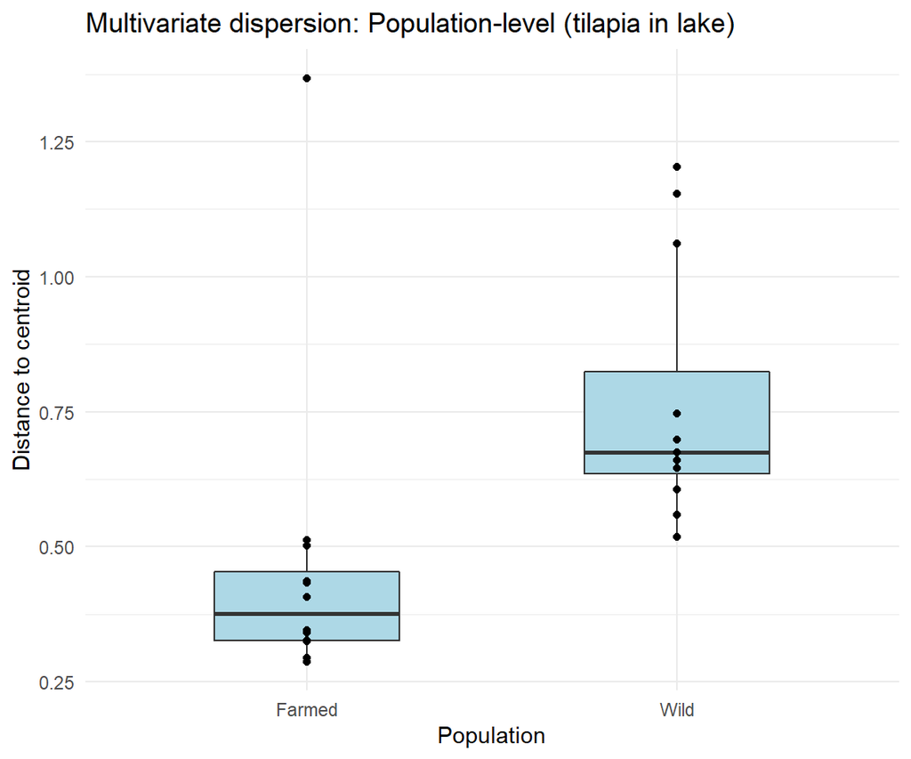

```r
plot_betadisper(
  disp_wuf_lake_pop,
  xlab = "Population",
  title = "Multivariate dispersion: Population-level (tilapia in lake)")
```